# Open data survey

# Question 26

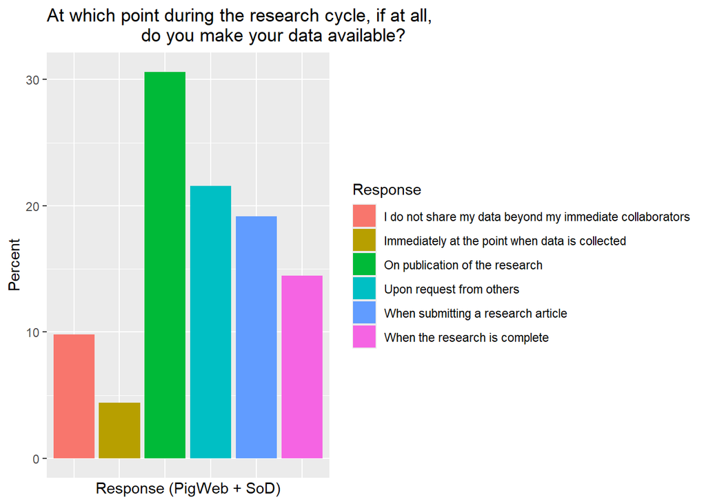

Figure 26

```r
#Creating data sets for Q26/Isolating the responses from Q26
pigw21Q26 = as.data.frame(dplyr::select(pigw21, 97))
pigw21Pile = cbind(pigw21Pile, pigw21Q26)

sod21Q26 = as.data.frame(dplyr::select(sod21, 31))
sod21Pile = cbind(sod21Pile, sod21Q26)

#Saving the Question text and changing the column name with the responses in the two data frames to Q26
Q26 = "At which point during the research cycle, if at all, do you make your data available?"
colnames(pigw21Q26) = c('Q26')
colnames(sod21Q26) = c('Q26')

#Changing names so answers from both surveys match
pigw21Q26$Q26[pigw21Q26$Q26 == "1"] <- "Immediately at the point when data is collected"
pigw21Q26$Q26[pigw21Q26$Q26 == "2"] <- "When the research is complete"
pigw21Q26$Q26[pigw21Q26$Q26 == "3"] <- "When submitting a research article"
pigw21Q26$Q26[pigw21Q26$Q26 == "4"] <- "On publication of the research"
  pigw21Q26$Q26[pigw21Q26$Q26 == "5"] <- "Upon request from others"
  pigw21Q26$Q26[pigw21Q26$Q26 == "6"] <- "I do not share my data beyond my immediate collaborators"


totalQ26 <- rbind(pigw21Q26, sod21Q26)

totalQ26 <- na.omit(totalQ26)

#sum(sod21Q26$Q26=="")

#table(sod21Q26$Q26)

merged_Q26 <- data.frame(
    Q26 = c(1:6),
    Response = c("Immediately at the point when data is collected", "When the research is complete",
                    "When submitting a research article", "On publication of the research",
                    "Upon request from others", "I do not share my data beyond my immediate collaborators"),
    stringsAsFactors = FALSE
)

merged_Q26$count <- c("192", "631",
                       "836", "1337",
                       "943", "428")

merged_Q26$count <- as.numeric(as.character(merged_Q26$count))
merged_Q26$Percent <- merged_Q26$count/sum(merged_Q26$count)*100

ggplot(data = merged_Q26, mapping = aes(x = Response, y = Percent, fill = Response)) +
  geom_bar(stat = "identity" ) +
  theme(axis.text.x=element_blank(),
        axis.ticks.x=element_blank()) +
          ggtitle("At which point during the research cycle, if at all,
                  do you make your data available?") +
            labs(y= "Percent", x = "Response (PigWeb + SoD)")
```

# Question 27

How do you share your research data with a public audience. Please select all that apply * Institutional repository * Funder repository * External repository * Blog/Website * Cloud file sharing * Other (please specify)

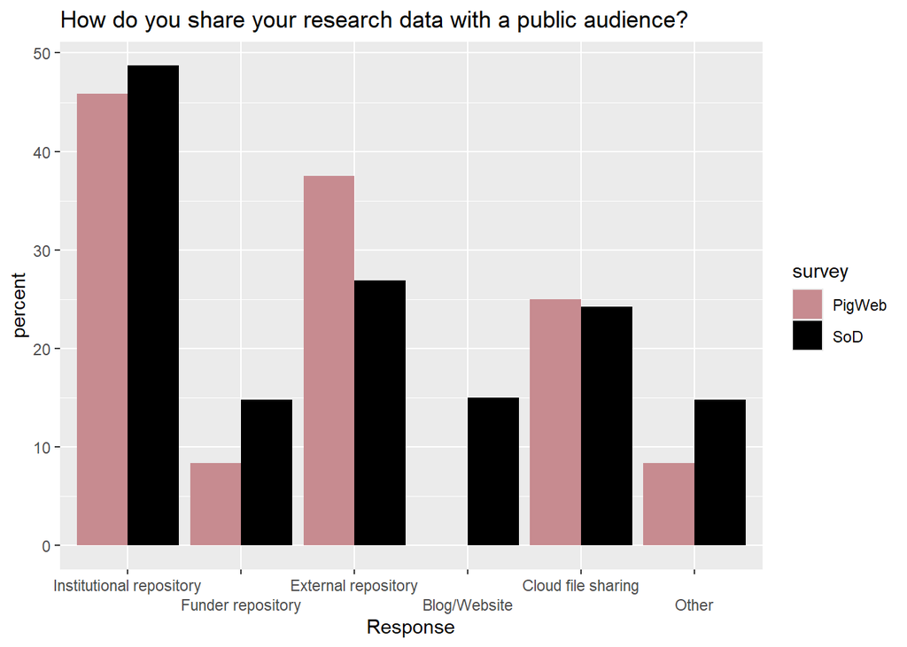

Figure 27

```r
# This is a multiple choice question with an 'other' option
# - This code chunk uses multiple choice functions

# Setting the answer options to Question 27
# - i.e. the ticks on the x axis when plotting
Q27_levels = c("Institutional repository",
              "Funder repository",
              "External repository",
              "Blog/Website",
              "Cloud file sharing",
              "Other")

# Create vector of the number of levels
# - Needed to extract columns corresponding to the questions in next step
n_columns <- length(Q27_levels)

# Create data frames of answers from both surveys
# - i.e. extracting the the multiple columns of the respective data frame that contains the answers
# Columns are selected by specifying the first column with a corresponding answer for the question, and telling R to extract the number of columns corresponding to the number of levels ('n_columns') with the exception of the 'other' column (indicated by -1 in the code below)
pigw21Q27 <- as.data.frame(dplyr::select(pigw21, (98:sum(98,n_columns,-1))))
sod21Q27 = as.data.frame(dplyr::select(sod21, (32:sum(32,n_columns,-1))))

# Add the questions to the 'pile' with all the other questions
pigw21Pile <- cbind(pigw21Pile, pigw21Q27)
sod21Pile <- cbind(sod21Pile, sod21Q27)

# Storing the question (used for plotting)
# - The plot title
Q27 <- 'How do you share your research data with a public audience?'


# Create a data frame containing percentages for each option for plotting multiple-choice questions
# - sod_data and pigweb_data are data frames of answers
# - levels is a vector of the options
# NB! sod_data must be before pigweb_data
Q27_data <- format_question_multiple_choice(sod21Q27,
                                          pigw21Q27,
                                          Q27_levels)

# Plot bar chart of percentages for a multiple response question (excluding 'other' option)
# Arguments (in order):
# - A data frame produced by format_question_multiple_choice
# - A vector of the answer options
# - A character string of the question which will be the title
# - A character string for the x-axis label (not a separate vector, write text below)
plot_multiple_choice(Q27_data,
                     Q27_levels,
                     Q27,
                     "Response")
```

```r
# Others responses
unique(pigw21[,104])
unique(sod21[,38])


pigw21Q27other = as.data.frame(pigw21[,104])
pigw21Pile = cbind(pigw21Pile, pigw21Q27other)

sod21Q27other = as.data.frame(sod21[,38])
sod21Pile = cbind(sod21Pile, sod21Q27other)
```

# Question 29

How, if at all, do you monitor the use of data that you share publicly? * Citations * Resolutions * Download * Altmetrics * I do not monitor the use of my data * Other(please specify)

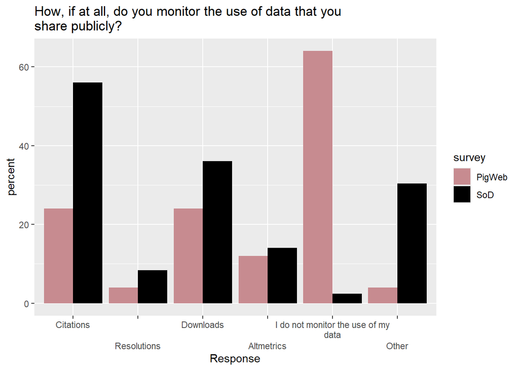

Figure 29

```r
# This is a multiple choice question with an 'other' option
# - This code chunk uses the multiple choice functions.

#Setting the answer options to Question 29
# - i.e. the ticks on the x axis when plotting
Q29_levels = c("Citations",
              "Resolutions",
              "Downloads",
              "Altmetrics",
              "I do not monitor the use of my data",
              "Other")

# Create vector of the number of levels
# - Needed to extract columns corresponding to the questions in next step
n_columns <- length(Q29_levels)

# Create data frames of answers from both surveys
# - i.e. extracting the the multiple columns of the respective data frame that contains the answers

# Columns are selected by specifying the first column with a corresponding answer for the question, and telling R to extract the number of columns corresponding to the number of levels ('n_columns') with the exception of the 'other' column (indicated by -1 in the code below)
pigw21Q29 <- as.data.frame(dplyr::select(pigw21, (106:sum(106,n_columns,-1))))
sod21Q29 = as.data.frame(dplyr::select(sod21, (53:sum(53,n_columns,-1))))

# Add the questions to the 'pile' with all the other questions
sod21Pile <- cbind(sod21Pile, sod21Q29)
pigw21Pile <- cbind(pigw21Pile, pigw21Q29)

# Storing the question (used for plotting)
# - The plot title
Q29 <- 'How, if at all, do you monitor the use of data that you share publicly?'

# Create a data frame containing percentages for each option for plotting multiple-choice questions
# - sod_data and pigweb_data are data frames of answers
# - levels is a vector of the options
# NB! sod_data must be before pigweb_data
Q29_data <- format_question_multiple_choice(sod21Q29,
                                          pigw21Q29,
                                          Q29_levels)

# Plot bar chart of percentages for a multiple response question (excluding 'other' option)
# Arguments (in order):
# - A data frame produced by format_question_multiple_choice
# - A vector of the answer options
# - A character string of the question which will be the title
# - A character string for the x-axis label (not a separate vector, write text below)
plot_multiple_choice(Q29_data,
                     Q29_levels,
                     Q29,
                     "Response")
```

```r
## Others responses
unique(pigw21[,111])
unique(sod21[,59])


pigw21Q29other = as.data.frame(pigw21[,111])
pigw21Pile = cbind(pigw21Pile, pigw21Q29other)

sod21Q29other = as.data.frame(sod21[,59])
sod21Pile = cbind(sod21Pile, sod21Q29other)
```

# Question 30

Have you ever been involved in a collaboration as a result of data you have previously shared? * Yes * No * I don’t know

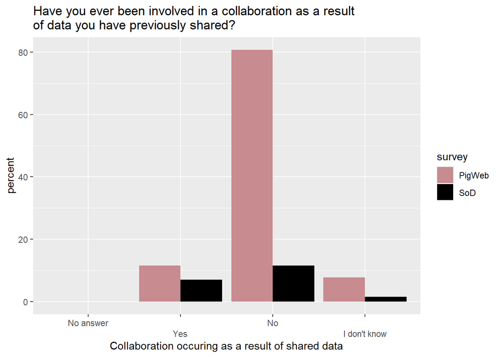

Figure 30

```r
# This is a single choice question without an "other" option
# - This code chunk uses single choice functions

# Create data frames of answers from both surveys
# - i.e. extracting the column of the respective data frame that contains the answers
pigw21Q30 <- as.data.frame(pigw21[,113])
sod21Q30 <- as.data.frame(sod21[,85])

# Add the questions to the 'pile' with all the other questions
pigw21Pile <- cbind(pigw21Pile, pigw21Q30)
sod21Pile <- cbind(sod21Pile, sod21Q30)

#Setting column names
colnames(sod21Q30) <- c('Q30')
colnames(pigw21Q30) <- c('Q30')

#Setting the answer options to Question 30
# - i.e. the ticks on the x axis when plotting
Q30 <- 'Have you ever been involved in a collaboration as a result of data you have previously shared?'

# Set the names of the answers
# - These are the names of the ticks on the x axis when plotting
Q30_levels <- c("Yes", "No", "I don't know")

# Create a data frame containing percentages for each option for plotting for single-choice questions
# - sod_data and pigweb_data are vectors of answers
# - levels is a vector of the options
# NB! sod_data must be before pigweb_data
Q30_data <- format_question_single_choice(sod21Q30$Q30,
                                          pigw21Q30$Q30,
                                          Q30_levels)

# Plot a bar chart of percentages for a single response question
# Arguments (in order):
# - A data frame produced by format_question_single_choice
# - A vector of the answer options
# - A character string of the question which will be the title
# - A character string for the x-axis label (not a separate vector, write text below)
plot_single_choice(Q30_data,
                   Q30_levels,
                   Q30,
                   "Collaboration occuring as a result of shared data")
```

# Question 31

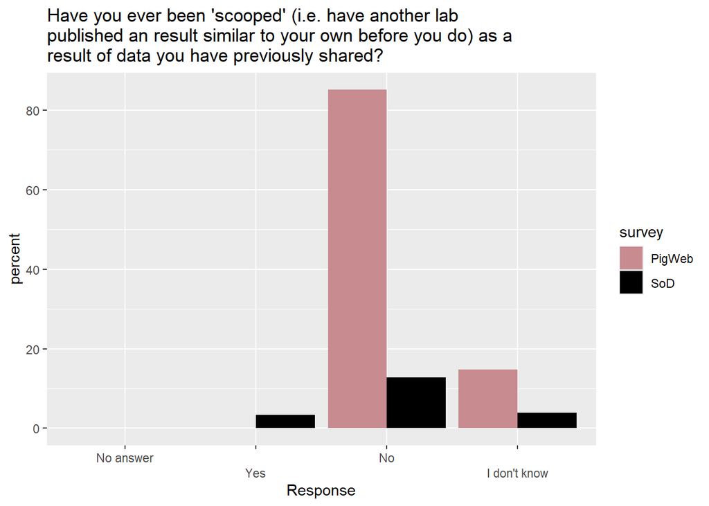

```r
#Creating data sets for Q31/Isolating the responses from Q31
pigw21Q31 = as.data.frame(dplyr::select(pigw21, 114))
pigw21Pile = cbind(pigw21Pile, pigw21Q31)

sod21Q31 = as.data.frame(dplyr::select(sod21, 86))
sod21Pile = cbind(sod21Pile, sod21Q31)

#Saving the Question text and changing the column name with the responses in the two data frames to Q31
Q31 = "Have you ever been 'scooped' (i.e. have another lab published an result similar to your own before you do) as a result of data you have previously shared?"
colnames(pigw21Q31) = c('Q31')
colnames(sod21Q31) = c('Q31')

Q31_levels = c("Yes", "No", "I don't know") #The different levels/categories of the questions

Q31_data = format_question_single_choice(sod21Q31$Q31, #Making the answers to Q31 in the two questionnaires comparable, merging them to one data frame
                                         pigw21Q31$Q31,
                                         Q31_levels)

plot_single_choice(Q31_data, #Plotting the responses
                   Q31_levels,
                   Q31,
                   "Response")
```

# Question 34

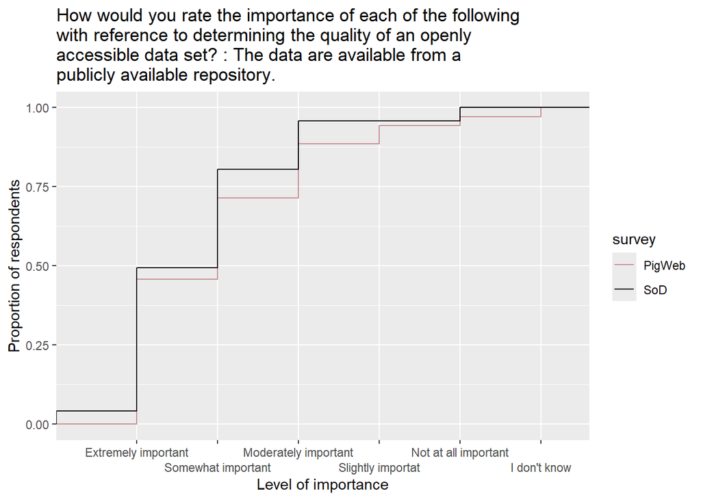

Figure Q34

```r
pigw21Q34 = as.data.frame(dplyr::select(pigw21, 126))
pigw21Pile = cbind(pigw21Pile, pigw21Q34)

#Setting column names and storing the question
colnames(pigw21Q34) = c('Q34')
Q34 = 'How would you rate the importance of each of the following with reference to determining the quality of an openly accessible data set? : The data are available from a publicly available repository.'

#Setting the answer options to Question Q19.
Q34_levels = c("Extremely important", "Somewhat important", "Moderately important", "Slightly importat", "Not at all important", "I don't know")

sod21Q34 = as.data.frame(dplyr::select(sod21,129))
sod21Pile = cbind(sod21Pile, sod21Q34)
colnames(sod21Q34) = c('Q34')


Q34_data = format_question_likert(sod21Q34$Q34,
                                 pigw21Q34$Q34,
                                 Q34_levels)

#Likert plot
plot_likert(Q34_data,
            Q34_levels,
            Q34,
            "Level of importance")
```

```r
#This section test for if there is statistically significant difference in the respondent groups
#with the null hypothesis that the two populations are the same.

ks.test(Q34_data$response[Q34_data$survey == "SoD"],
        Q34_data$response[Q34_data$survey == "PigWeb"],
        ifresult = FALSE) #Kolmogorov-Smirnov test for Q34
```

[output not shown]

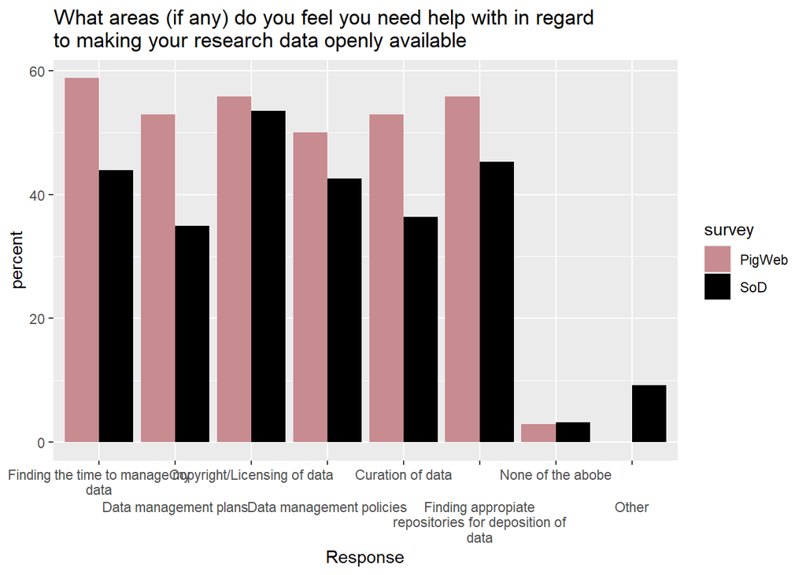

Figure QP3

```r
#Paulina Q3
#What areas (if any) do you feel you need help with in regard to making your research data openly available.
#This code chunk uses the multiple choice functions.
QP3_levels = c("Finding the time to manage my data",
              "Data management plans",
              "Copyright/Licensing of data",
              "Data management policies",
              "Curation of data",
              "Finding appropiate repositories for deposition of data",
              "None of the abobe",
              "Other")
n_columns = length(QP3_levels)

sod21QP3 = as.data.frame(dplyr::select(sod21, (87:sum(87,n_columns,-1))))
sod21Pile = cbind(sod21Pile, sod21QP3)

pigw21QP3 = as.data.frame(dplyr::select(pigw21, (67:sum(67,n_columns-1))))
pigw21Pile = cbind(pigw21Pile, pigw21QP3)

QP3 = 'What areas (if any) do you feel you need help with in regard to making your research data openly available'


QP3_data = format_question_multiple_choice(sod21QP3,
                                          pigw21QP3,
                                          QP3_levels)

plot_multiple_choice(QP3_data,
                     QP3_levels,
                     QP3,
                     "Response")
```

#Question 45

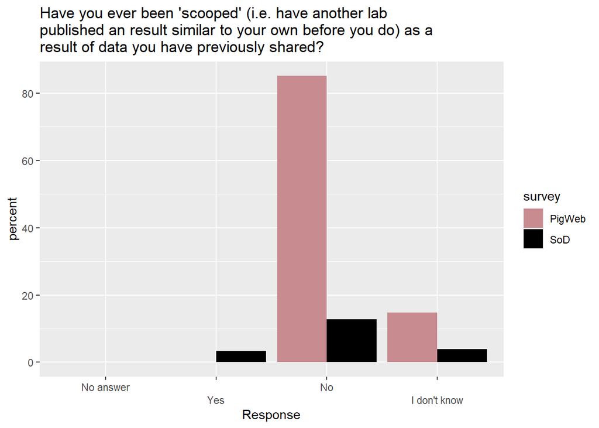

Figure 45

```r
#Creating data sets for Q45/Isolating the responses from Q45
pigw21Q45 = as.data.frame(dplyr::select(pigw21, 114))
pigw21Pile = cbind(pigw21Pile, pigw21Q45)

sod21Q45 = as.data.frame(dplyr::select(sod21, 86))
sod21Pile = cbind(sod21Pile, sod21Q45)

#Saving the Question text and changing the column name with the responses in the two data frames to Q45
Q45 = "Have you ever been 'scooped' (i.e. have another lab published an result similar to your own before you do) as a result of data you have previously shared?"
colnames(pigw21Q45) = c('Q45')
colnames(sod21Q45) = c('Q45')

Q45_levels = c("Yes", "No", "I don't know") #The different levels/categories of the questions

Q45_data = format_question_single_choice(sod21Q45$Q45, #Making the answers to Q45 in the two questionnaires comparable, merging them to one data frame
                                         pigw21Q45$Q45,
                                         Q45_levels)

plot_single_choice(Q45_data, #Plotting the responses
                   Q45_levels,
                   Q45,
                   "Response")
```

#Léonie assignement

“Questions.about.your.usage.of.other.data.sources How.would.you.rate.the.importance.of.each.of.the.following.with.reference.to.determining.the.quality.of.an.openly.accessible.data.set..Use.the.arrows.below.to.go.to.next.statement..there.is.a.total.of.12.statements.to.respond.to.here…..The.data.are.new..e.g..released.within.the.last.year.”

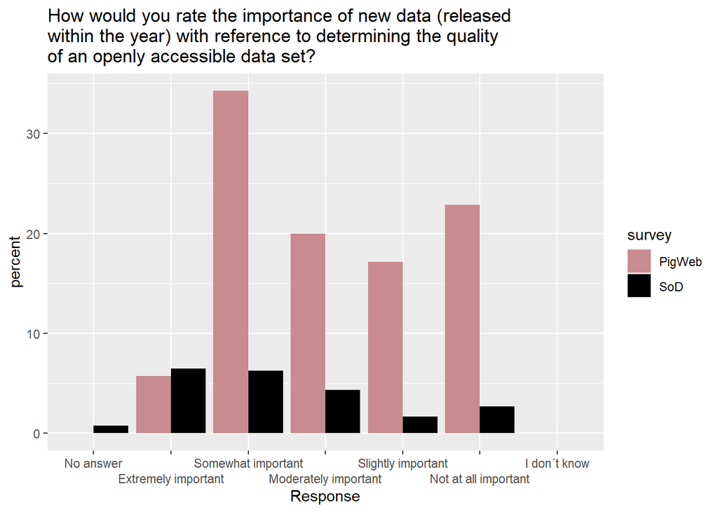

```r
#Creating data sets for column 125 and 128
pigw21Qleonie1 = as.data.frame(dplyr::select(pigw21, 125))
pigw21Pile = cbind(pigw21Pile, pigw21Qleonie1)

sod21Qleonie1 = as.data.frame(dplyr::select(sod21, 128))
sod21Pile = cbind(sod21Pile, sod21Qleonie1)



#Saving the Question text and changing the column name with the responses in the two data frames to Q45
Qleonie1 = "How would you rate the importance of new data (released within the year) with reference to determining the quality of an openly accessible data set? "
colnames(pigw21Qleonie1 ) = c('Qleonie1 ')
colnames(sod21Qleonie1 ) = c('Qleonie1 ')

Qleonie1_levels = c("Extremely important", "Somewhat important", "Moderately important","Slightly important","Not at all important","I don´t know") #The different levels/categories of the questions

Qleonie1_data = format_question_single_choice(sod21Qleonie1$Qleonie1, #Making the answers to Q45 in the two questionnaires comparable, merging them to one data frame
                                         pigw21Qleonie1$Qleonie1,
                                         Qleonie1_levels)

plot_single_choice(Qleonie1_data, #Plotting the responses
                   Qleonie1_levels,
                  Qleonie1,
                   "Response")
```

About.your.research.data…Are.you.aware.of.any.of.the.following.data.or.code.sharing.platforms….EOSC..European.Open.Science.Cloud.

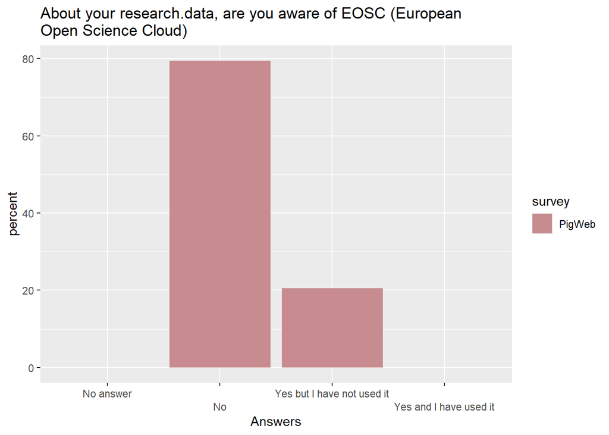

```r
#This is a single choice question without an "other" with responses only in the PigWeb survey.

pigw21Qleonie2 = as.data.frame(dplyr::select(pigw21, 89))


Qleonie2 = 'About your research.data, are you aware of EOSC (European Open Science Cloud)'
colnames(pigw21Qleonie2) = c('Qleonie2')

Qleonie2_levels = c("No", "Yes but I have not used it ", "Yes and I have used it")

#The function is given a 0 instead of the column expected form the SoD survey as there is no question in it.
Qleonie2_data = format_question_single_choice_pigweb(pigw21Qleonie2$Qleonie2,
                                       Qleonie2_levels)

plot_single_choice(Qleonie2_data,
                   Qleonie2_levels,
                   Qleonie2 ,
                   "Answers")
```